## Project:Restaurant Bills & Tip Analysis Using Pandas

```python
import numpy as np
import pandas as pd
import seaborn as sns
from matplotlib import pyplot as plt
```

```python
df=sns.load_dataset("tips")
```

```python
df
```

|  | total_bill | tip | sex | smoker | day | time | size |
| --- | --- | --- | --- | --- | --- | --- | --- |
| 0 | 16.99 | 1.01 | Female | No | Sun | Dinner | 2 |
| 1 | 10.34 | 1.66 | Male | No | Sun | Dinner | 3 |
| 2 | 21.01 | 3.50 | Male | No | Sun | Dinner | 3 |
| 3 | 23.68 | 3.31 | Male | No | Sun | Dinner | 2 |
| 4 | 24.59 | 3.61 | Female | No | Sun | Dinner | 4 |
| ... | ... | ... | ... | ... | ... | ... | ... |
| 239 | 29.03 | 5.92 | Male | No | Sat | Dinner | 3 |
| 240 | 27.18 | 2.00 | Female | Yes | Sat | Dinner | 2 |
| 241 | 22.67 | 2.00 | Male | Yes | Sat | Dinner | 2 |
| 242 | 17.82 | 1.75 | Male | No | Sat | Dinner | 2 |
| 243 | 18.78 | 3.00 | Female | No | Thur | Dinner | 2 |

244 rows × 7 columns

##### why we use df.info():

df.info() is used to understand the structure of dataset

- Totel number of rows
- Totel number of columns
- column names
- Data types
- Missing values
- This helps us check if the data is clean or if it needs preprocessing

```python
df.info()
```

```
<class 'pandas.core.frame.DataFrame'>
RangeIndex: 244 entries, 0 to 243
Data columns (total 7 columns):
 #   Column      Non-Null Count  Dtype
---  ------      --------------  -----
 0   total_bill  244 non-null    float64
 1   tip         244 non-null    float64
 2   sex         244 non-null    category
 3   smoker      244 non-null    category
 4   day         244 non-null    category
 5   time        244 non-null    category
 6   size        244 non-null    int64
dtypes: category(4), float64(2), int64(1)
memory usage: 7.4 KB
```

#### why we used head() and tail():

to check the consistency of data

```python
df.head()
```

|  | total_bill | tip | sex | smoker | day | time | size |
| --- | --- | --- | --- | --- | --- | --- | --- |
| 0 | 16.99 | 1.01 | Female | No | Sun | Dinner | 2 |
| 1 | 10.34 | 1.66 | Male | No | Sun | Dinner | 3 |
| 2 | 21.01 | 3.50 | Male | No | Sun | Dinner | 3 |
| 3 | 23.68 | 3.31 | Male | No | Sun | Dinner | 2 |
| 4 | 24.59 | 3.61 | Female | No | Sun | Dinner | 4 |

```python
df.tail()
```

|  | total_bill | tip | sex | smoker | day | time | size |
| --- | --- | --- | --- | --- | --- | --- | --- |
| 239 | 29.03 | 5.92 | Male | No | Sat | Dinner | 3 |
| 240 | 27.18 | 2.00 | Female | Yes | Sat | Dinner | 2 |
| 241 | 22.67 | 2.00 | Male | Yes | Sat | Dinner | 2 |
| 242 | 17.82 | 1.75 | Male | No | Sat | Dinner | 2 |
| 243 | 18.78 | 3.00 | Female | No | Thur | Dinner | 2 |

#### why we use df.describe( include=all):

it gives statistical summary of both numeric and categorical columns

- count( no.of non_null values)
- unique(no.of unique values)
- top(most repeated value)
- freq(how many times repeat the value)
- mean(average)
- std,min ,max,25%,50%(median),75%
- it helps us understand the distribution of data

```python
df.describe(include="all")
```

|  | total_bill | tip | sex | smoker | day | time | size |
| --- | --- | --- | --- | --- | --- | --- | --- |
| count | 244.000000 | 244.000000 | 244 | 244 | 244 | 244 | 244.000000 |
| unique | NaN | NaN | 2 | 2 | 4 | 2 | NaN |
| top | NaN | NaN | Male | No | Sat | Dinner | NaN |
| freq | NaN | NaN | 157 | 151 | 87 | 176 | NaN |
| mean | 19.785943 | 2.998279 | NaN | NaN | NaN | NaN | 2.569672 |
| std | 8.902412 | 1.383638 | NaN | NaN | NaN | NaN | 0.951100 |
| min | 3.070000 | 1.000000 | NaN | NaN | NaN | NaN | 1.000000 |
| 25% | 13.347500 | 2.000000 | NaN | NaN | NaN | NaN | 2.000000 |
| 50% | 17.795000 | 2.900000 | NaN | NaN | NaN | NaN | 2.000000 |
| 75% | 24.127500 | 3.562500 | NaN | NaN | NaN | NaN | 3.000000 |
| max | 50.810000 | 10.000000 | NaN | NaN | NaN | NaN | 6.000000 |

#### why we add a "tip percentage" column:

Dataset contains total bill and tip amount,but these values cannot show how generous acustomer really is. for example,20 rupees tip on 500 bill is less generous than 10 rupees tip on 100 bill so we create this column. it helps us comparing tipping behavior across diffrent customers

```python
df["tip_percentage"]=df["tip"]/df["total_bill"]*100
```

```python
df
```

|  | total_bill | tip | sex | smoker | day | time | size | tip_percentage |
| --- | --- | --- | --- | --- | --- | --- | --- | --- |
| 0 | 16.99 | 1.01 | Female | No | Sun | Dinner | 2 | 5.944673 |
| 1 | 10.34 | 1.66 | Male | No | Sun | Dinner | 3 | 16.054159 |
| 2 | 21.01 | 3.50 | Male | No | Sun | Dinner | 3 | 16.658734 |
| 3 | 23.68 | 3.31 | Male | No | Sun | Dinner | 2 | 13.978041 |
| 4 | 24.59 | 3.61 | Female | No | Sun | Dinner | 4 | 14.680765 |
| ... | ... | ... | ... | ... | ... | ... | ... | ... |
| 239 | 29.03 | 5.92 | Male | No | Sat | Dinner | 3 | 20.392697 |
| 240 | 27.18 | 2.00 | Female | Yes | Sat | Dinner | 2 | 7.358352 |
| 241 | 22.67 | 2.00 | Male | Yes | Sat | Dinner | 2 | 8.822232 |
| 242 | 17.82 | 1.75 | Male | No | Sat | Dinner | 2 | 9.820426 |
| 243 | 18.78 | 3.00 | Female | No | Thur | Dinner | 2 | 15.974441 |

244 rows × 8 columns

#### Average bill by gender

- we take average bill by gender to see who pays more on average- men or women
- to see is there any diffrence in customer behavior

```python
df.groupby("sex")["total_bill"].mean()
```

[output not shown]

```
sex
Male      20.744076
Female    18.056897
Name: total_bill, dtype: float64
```

#### Average tip percentage by day

Different days of the week may have different customer behaviors. To understand tipping patterns, we calculate the average tip percentage for each day.

```python
df.groupby("day")["tip_percentage"].mean()
```

[output not shown]

```
day
Thur    16.127563
Fri     16.991303
Sat     15.315172
Sun     16.689729
Name: tip_percentage, dtype: float64
```

#### who gives more tips ? smoker or non smoker

- who tips more generously?
- do smokers leave bigger tips?
- is there a diffrence in spending behavior?
- do non_smokers tips less or more?

```python
df.groupby("smoker")["tip"].mean()
```

[output not shown]

```
smoker
Yes    3.008710
No     2.991854
Name: tip, dtype: float64
```

#### why we use data visualization

it converts raw numbers into meaningfull harts and graphs

- it helps us quickly see patterns in the data
- it communicate insights more clearly than tables
- it shows the distribution of values and helps identify outliers
- it helps to detect errors
- it makes comparision between groups

#### visualization:total bill vs tips

- scatter plpt:it shows the relationship between two numerical columns

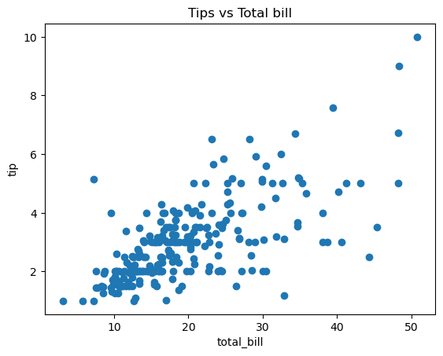

```python
plt.scatter(df["total_bill"],df["tip"])
plt.xlabel("total_bill")
plt.ylabel("tip")
plt.title("Tips vs Total bill")
plt.show()
```

#### Average tip by gender

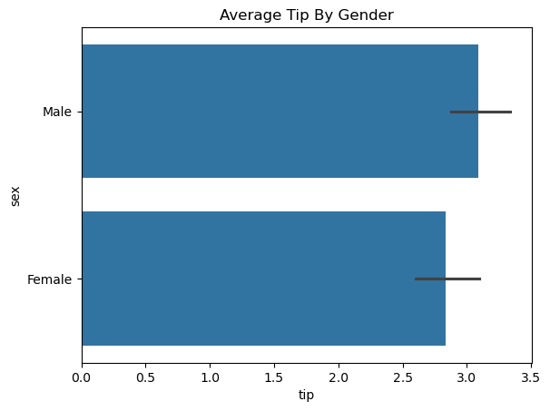

```python
sns.barplot(data=df,x='tip',y='sex')
plt.title("Average Tip By Gender")
plt.show()
```

### Average Tip by Gender (Bar Plot)

This bar plot shows the average tip amount given by male and female customers. The x-axis represents the average tip, and the y-axis shows the gender categories. From the plot, we can observe:

- Male customers tip slightly more on average than female customers.
- The bar length represents the mean tip amount.
- The small horizontal black line on each bar is the confidence interval, which shows the variation in the tip values. This visualization makes it easy to compare tipping behavior between different genders.